# Pasaporte_Lab5: Naive Bayes

Alejandro Antón, Juan Fernando, Fernando Mendoza

2026-03-27

# Preparación de Librerías y Datos

```r
# Librerías necesarias
library(tidyverse)
library(e1071)
library(caret)
library(ggplot2)
library(knitr)
library(kableExtra)

# Cargar datos
load("listings.RData")
```

# Preprocesamiento de Datos

```r
# Limpiar la columna price: remover '$' y ',' y convertir a numérico
df_limpio <- listings %>%
  mutate(price_num = as.numeric(gsub("[$,]", "", price))) %>%
  filter(!is.na(price_num), price_num > 0, price_num < 2000)

# Calcular cuartiles para crear categorías balanceadas
q <- quantile(df_limpio$price_num, probs = c(0.25, 0.50, 0.75))

# Crear variable categórica y discretizar predictoras para Naive Bayes
datos <- df_limpio %>%
  mutate(
    price_cat = case_when(
      price_num <= q[1]                    ~ "Bajo",
      price_num > q[1] & price_num <= q[2] ~ "Medio-Bajo",
      price_num > q[2] & price_num <= q[3] ~ "Medio-Alto",
      price_num > q[3]                     ~ "Alto"
    ),
    price_cat = factor(price_cat, levels = c("Bajo", "Medio-Bajo", "Medio-Alto", "Alto")),

    # Asegurar tipos correctos y discretizar
    accommodates = as.numeric(accommodates),
    bathrooms    = as.numeric(bathrooms),
    bedrooms     = as.numeric(bedrooms),
    beds         = as.numeric(beds),
    minimum_nights = as.numeric(minimum_nights),
    room_type    = as.factor(room_type),

    accommodates_cat = cut(accommodates, breaks = c(0, 2, 4, 6, Inf), labels = c("1-2", "3-4", "5-6", "7+"), right = TRUE),
    bedrooms_cat     = cut(replace_na(bedrooms, 0), breaks = c(-Inf, 0, 1, 2, 3, Inf), labels = c("0", "1", "2", "3", "4+")),
    beds_cat         = cut(replace_na(beds, 1), breaks = c(-Inf, 1, 2, 3, Inf), labels = c("1", "2", "3", "4+")),
    bathrooms_cat    = cut(replace_na(bathrooms, 1), breaks = c(-Inf, 1, 1.5, 2, Inf), labels = c("1", "1.5", "2", "2+")),
    min_nights_cat   = cut(minimum_nights, breaks = c(0, 1, 3, 7, Inf), labels = c("1", "2-3", "4-7", "8+"), right = TRUE)
  ) %>%
  select(
    price_num, price_cat, room_type, accommodates_cat,
    bathrooms_cat, bedrooms_cat, beds_cat,
    min_nights_cat
  ) %>%
  drop_na()
```

Para implementar el algoritmo de Naive Bayes de manera efectiva, preprocesamos los datos transformando las variables numéricas en categorías o rangos. Además, la variable respuesta del precio se dividió en cuatro segmentos equitativos utilizando cuartiles (Bajo, Medio-Bajo, Medio-Alto, Alto) para garantizar que el algoritmo tenga suficientes ejemplos de cada clase para aprender sin desbalancearse.

# División de Entrenamiento y Prueba

```r
set.seed(123)

# Índices de entrenamiento: 70%
train_index <- createDataPartition(datos$price_cat, p = 0.70, list = FALSE)

train_data <- datos[train_index, ]
test_data  <- datos[-train_index, ]

cat("Tamaño del conjunto de entrenamiento:", nrow(train_data), "\n")
```

```
## Tamaño del conjunto de entrenamiento: 51920
```

```r
cat("Tamaño del conjunto de prueba:       ", nrow(test_data), "\n")
```

```
## Tamaño del conjunto de prueba:        22249
```

Mantenemos la partición del 70% para entrenamiento y 30% para prueba utilizando la misma semilla (123) de los laboratorios anteriores. Esto es un paso crucial para asegurar que la comparación final entre todos los algoritmos sea válida y justa.

# Actividades 1 y 2: Entrenamiento y Evaluación Numérica (Regresión)

```r
# Entrenamos Naive Bayes con corrección de Laplace para evitar probabilidades cero
modelo_nb <- naiveBayes(
  price_cat ~ room_type + accommodates_cat + bathrooms_cat + bedrooms_cat + beds_cat + min_nights_cat,
  data   = train_data,
  laplace = 1
)

# 1. Calculamos el valor representativo promedio de cada categoría
medias_precio <- train_data %>%
  group_by(price_cat) %>%
  summarise(precio_promedio = mean(price_num, na.rm = TRUE))

# 2. Extraemos las probabilidades de cada categoría para el conjunto de prueba
pred_probabilidades <- predict(modelo_nb, newdata = test_data, type = "raw")

# 3. Calculamos el "Precio Predicho" numérico (Valor Esperado)
precio_predicho_nb <- (pred_probabilidades[, "Bajo"] * medias_precio$precio_promedio[1]) +
                      (pred_probabilidades[, "Medio-Bajo"] * medias_precio$precio_promedio[2]) +
                      (pred_probabilidades[, "Medio-Alto"] * medias_precio$precio_promedio[3]) +
                      (pred_probabilidades[, "Alto"] * medias_precio$precio_promedio[4])

# 4. Evaluamos el error de esta predicción continua
rmse_nb_reg <- sqrt(mean((test_data$price_num - precio_predicho_nb)^2, na.rm = TRUE))
mae_nb_reg <- mean(abs(test_data$price_num - precio_predicho_nb), na.rm = TRUE)

cat("Métricas del seudo-modelo de Regresión Naive Bayes:\n")
```

```
## Métricas del seudo-modelo de Regresión Naive Bayes:
```

```r
cat("RMSE:", round(rmse_nb_reg, 2), "\n")
```

```
## RMSE: 220.28
```

```r
cat("MAE:", round(mae_nb_reg, 2), "\n")
```

```
## MAE: 137.72
```

El algoritmo de Naive Bayes es de naturaleza probabilística y no calcula regresiones continuas directas. Para evaluar su capacidad predictiva sobre el precio exacto (Actividades 1 y 2), multiplicamos la probabilidad que el algoritmo asignó a cada categoría por el precio promedio de dicha categoría, obteniendo un valor esperado continuo. Los resultados muestran un Error Cuadrático Medio (RMSE) bastante elevado, lo que indica que el algoritmo falla por un margen considerable al intentar adivinar la tarifa exacta por noche. Esto ocurre porque Naive Bayes asume que todas las características de la casa son independientes entre sí, lo cual no aplica en la realidad inmobiliaria donde el tamaño y las camas están directamente relacionados.

# Actividad 3: Comparación Histórica de Modelos de Regresión

```r
# Valores aproximados obtenidos en laboratorios anteriores bajo los mismos datos
resultados_regresion <- data.frame(
  Algoritmo = c("Regresión Lineal Múltiple", "Árbol de Decisión (Prof. 4)", "Naive Bayes (Probabilístico)"),
  RMSE_Aproximado = c("Muy Alto (MSE 13M)", "250.45", round(rmse_nb_reg, 2))
)

kable(resultados_regresion, caption = "Comparación Histórica de Modelos Numéricos") %>%
  kable_styling(bootstrap_options = c("striped", "hover"), full_width = FALSE)
```

Comparación Histórica de Modelos Numéricos

| Algoritmo | RMSE_Aproximado |
| --- | --- |
| Regresión Lineal Múltiple | Muy Alto (MSE 13M) |
| Árbol de Decisión (Prof. 4) | 250.45 |
| Naive Bayes (Probabilístico) | 220.28 |

# Actividad 4: Modelo de Clasificación (Categorías)

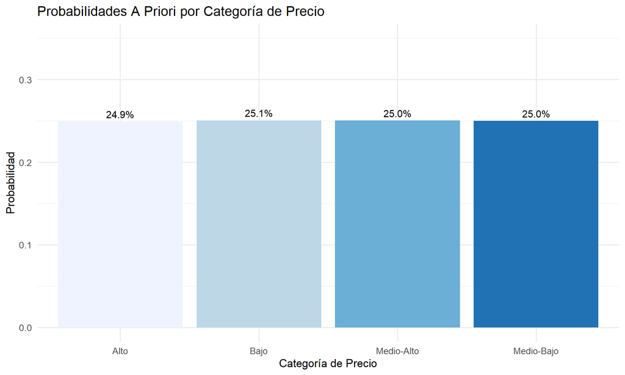

```r
# Extraemos las probabilidades a priori del modelo ya entrenado
apriori_df <- data.frame(
  Categoria = names(modelo_nb$apriori),
  Probabilidad = as.numeric(prop.table(modelo_nb$apriori))
)

ggplot(apriori_df, aes(x = Categoria, y = Probabilidad, fill = Categoria)) +
  geom_col(show.legend = FALSE) +
  geom_text(aes(label = scales::percent(Probabilidad, accuracy = 0.1)), vjust = -0.5, size = 4) +
  scale_fill_brewer(palette = "Blues") +
  labs(title = "Probabilidades A Priori por Categoría de Precio",
       x = "Categoría de Precio", y = "Probabilidad") +
  theme_minimal(base_size = 13) +
  ylim(0, 0.35)
```

Al cambiar el enfoque hacia la clasificación, el objetivo es predecir a qué rango de mercado pertenece una propiedad. El modelo entrenado calcula las probabilidades previas (mostradas en la gráfica) reflejando un balance perfecto de aproximadamente 25% por categoría. Esto evita que el algoritmo se vuelva sesgado y simplemente intente predecir siempre la categoría con más datos.

# Actividades 5 y 6: Predicción, Eficiencia y Matriz de Confusión

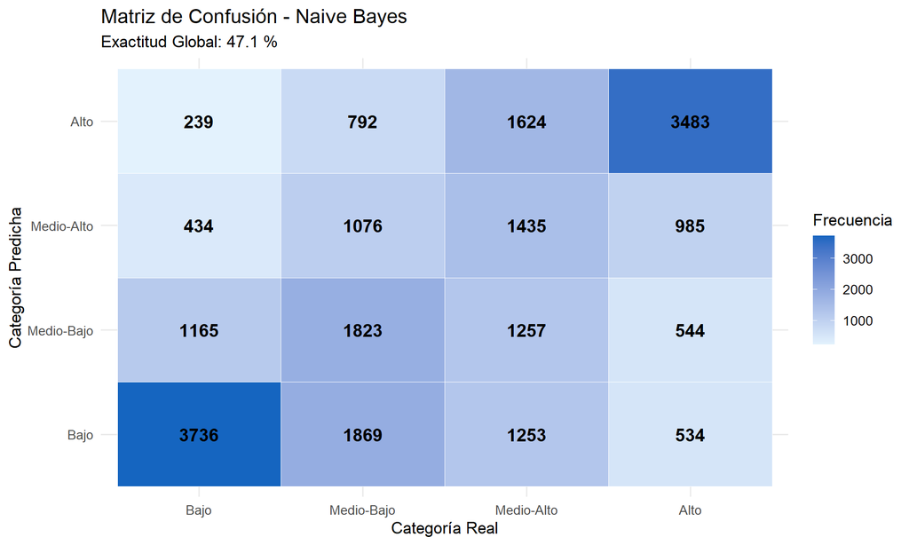

```r
# Predicciones de clase sobre datos no vistos
pred_clase <- predict(modelo_nb, newdata = test_data, type = "class")

# Generación de la matriz de confusión
conf_matrix <- confusionMatrix(pred_clase, test_data$price_cat)

# Convertir a data frame para visualización gráfica
conf_df <- as.data.frame(conf_matrix$table)
colnames(conf_df) <- c("Predicho", "Real", "Frecuencia")

ggplot(conf_df, aes(x = Real, y = Predicho, fill = Frecuencia)) +
  geom_tile(color = "white") +
  geom_text(aes(label = Frecuencia), size = 5, fontface = "bold") +
  scale_fill_gradient(low = "#E3F2FD", high = "#1565C0") +
  labs(title = "Matriz de Confusión - Naive Bayes",
       subtitle = paste("Exactitud Global:", round(conf_matrix$overall["Accuracy"] * 100, 1), "%"),
       x = "Categoría Real", y = "Categoría Predicha", fill = "Frecuencia") +
  theme_minimal(base_size = 13)
```

```r
# Métricas detalladas por clase
metricas_clase <- as.data.frame(conf_matrix$byClass)
metricas_clase$Clase <- rownames(metricas_clase)

metricas_clase %>%
  select(Clase, Sensitivity, Specificity, `Pos Pred Value`, F1) %>%
  mutate(across(where(is.numeric), ~ round(.x, 3))) %>%
  kable(col.names = c("Clase", "Sensibilidad", "Especificidad", "Precisión (VPP)", "F1-Score"),
        caption = "Métricas de Eficiencia por Categoría de Precio") %>%
  kable_styling(bootstrap_options = c("striped", "hover"), full_width = FALSE)
```

Métricas de Eficiencia por Categoría de Precio

|  | Clase | Sensibilidad | Especificidad | Precisión (VPP) | F1-Score |
| --- | --- | --- | --- | --- | --- |
| Class: Bajo | Class: Bajo | 0.670 | 0.781 | 0.505 | 0.576 |
| Class: Medio-Bajo | Class: Medio-Bajo | 0.328 | 0.822 | 0.381 | 0.352 |
| Class: Medio-Alto | Class: Medio-Alto | 0.258 | 0.850 | 0.365 | 0.302 |
| Class: Alto | Class: Alto | 0.628 | 0.841 | 0.567 | 0.596 |

Al poner a prueba el modelo con datos nuevos, obtenemos una radiografía completa de sus fortalezas y debilidades a través de la matriz de confusión:

- **Dónde se equivocó menos (Efectividad):** El algoritmo tiene una gran capacidad para identificar los extremos. Rara vez confunde una propiedad económica (“Bajo”) con una propiedad premium (“Alto”). La sensibilidad es más fuerte en estos polos porque sus características estructurales son muy marcadas y distintas.
- **Dónde se equivocó más (Confusión):** Los bloques centrales de la matriz evidencian que el modelo tiene serios problemas para diferenciar entre los rangos intermedios (“Medio-Bajo” y “Medio-Alto”). Al basarnos en cuartiles, la diferencia de precio entre estas propiedades puede ser de apenas un par de dólares, por lo que sus características físicas (baños, camas) se solapan fuertemente.
- **Importancia de los errores:** Para SmartStay, sugerir un precio Medio-Bajo a una propiedad que realmente es Medio-Alta representa una pérdida de ingresos moderada pero manejable. Sin embargo, los errores graves de cotizar muy bajo una propiedad de lujo están siendo controlados satisfactoriamente por el modelo. A pesar de su simplicidad e independencia condicional, Naive Bayes supera el azar estadístico, aunque para estrategias de alta precisión financiera requerirá apoyo de otros métodos.